# Diagnóstico de variables del modelo

## 1 Objetivo

Documentar el diagnóstico de colinealidad y selección de variables para los modelos a nivel `cluster_id`/`dia`.

El diagnóstico se genera con:

- `scripts/diagnostico_variables_modelo_cluster_dia.R`

Salidas:

- `data/processed/modelos/diagnostico_variables/`

## 2 Carga de resultados

## 3 Resumen general

Resumen del diagnostico de variables

| variables_originales | correlaciones_altas | variables_con_vif_infinito | version_cluster | fecha_min_modelo | meses_train | meses_validacion |
| --- | --- | --- | --- | --- | --- | --- |
| 15 | 2 | 0 | v2026_05_25 | 2025-01-08 | 202501,202502,202503,202504,202505,202506,202507,202508,202509,202510,202511,202512 | 202601,202602,202603 |

## 4 Faltantes y distribución

Resumen de predictores en entrenamiento

| variable | pct_na | media | desvio | p05 | mediana | p95 | max |
| --- | --- | --- | --- | --- | --- | --- | --- |
| mean_tiempo_desde_ultimo_levante_pred | 0.002 | 1.6535 | 1.1903 | 0.2191 | 1.4862 | 3.8186 | 20.4513 |
| dias_cluster_existente_30d | 0.000 | 28.7794 | 4.5375 | 18.0000 | 30.0000 | 30.0000 | 30.0000 |
| dias_desde_ultimo_reclamo_o_inicio_trunc_90 | 0.000 | 23.9018 | 28.4857 | 1.0000 | 11.0000 | 90.0000 | 90.0000 |
| historia_observada_180_mas | 0.000 | 0.4503 | 0.4975 | 0.0000 | 0.0000 | 1.0000 | 1.0000 |
| historia_observada_30_89 | 0.000 | 0.1904 | 0.3926 | 0.0000 | 0.0000 | 1.0000 | 1.0000 |
| historia_observada_7_29 | 0.000 | 0.0747 | 0.2630 | 0.0000 | 0.0000 | 1.0000 | 1.0000 |
| historia_observada_90_179 | 0.000 | 0.2748 | 0.4464 | 0.0000 | 0.0000 | 1.0000 | 1.0000 |
| mean_dias_total_tramo_inferido_estado | 0.000 | 1.1409 | 1.3663 | 0.0000 | 1.0000 | 3.0000 | 15.0000 |
| mean_levante_periodo | 0.000 | 2.1572 | 0.4842 | 1.0000 | 2.3300 | 3.0000 | 3.5000 |
| n_contenedores_activos | 0.000 | 1.3520 | 0.7481 | 1.0000 | 1.0000 | 3.0000 | 17.0000 |
| n_reclamos_lag1 | 0.000 | 0.1468 | 0.5390 | 0.0000 | 0.0000 | 1.0000 | 68.0000 |
| n_reclamos_sum_30d | 0.000 | 4.2248 | 7.0879 | 0.0000 | 2.0000 | 16.0000 | 248.0000 |
| n_reclamos_sum_7d | 0.000 | 1.0216 | 2.1200 | 0.0000 | 0.0000 | 4.0000 | 116.0000 |
| pct_contenedores_inferidos | 0.000 | 0.5192 | 0.4961 | 0.0000 | 1.0000 | 1.0000 | 1.0000 |
| sin_reclamo_previo_observado | 0.000 | 0.1182 | 0.3228 | 0.0000 | 0.0000 | 1.0000 | 1.0000 |

## 5 Correlaciones altas

Se listan pares de variables con correlacion absoluta alta en la matriz preparada para el modelo.

Principales correlaciones altas

| variable_1 | variable_2 | correlacion | abs_correlacion |
| --- | --- | --- | --- |
| mean_dias_total_tramo_inferido_estado | pct_contenedores_inferidos | 0.7970 | 0.7970 |
| n_reclamos_sum_30d | n_reclamos_sum_7d | 0.7673 | 0.7673 |

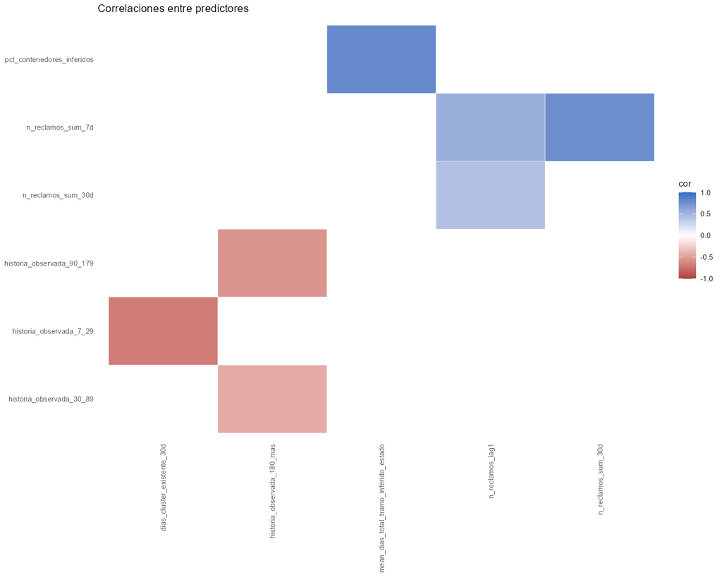

## 6 VIF

El VIF resume cuanto puede explicarse cada predictor con los demas. Valores muy altos indican colinealidad fuerte.

Variables con mayor VIF

| variable | r2_contra_otros_predictores | vif |
| --- | --- | --- |
| historia_observada_180_mas | 0.9847 | 65.46 |
| historia_observada_90_179 | 0.9810 | 52.74 |
| historia_observada_30_89 | 0.9754 | 40.62 |
| historia_observada_7_29 | 0.9104 | 11.16 |
| dias_cluster_existente_30d | 0.7863 | 4.68 |
| pct_contenedores_inferidos | 0.7080 | 3.42 |
| mean_dias_total_tramo_inferido_estado | 0.6579 | 2.92 |
| n_reclamos_sum_7d | 0.6546 | 2.90 |
| n_reclamos_sum_30d | 0.6270 | 2.68 |
| dias_desde_ultimo_reclamo_o_inicio_trunc_90 | 0.3640 | 1.57 |
| sin_reclamo_previo_observado | 0.3544 | 1.55 |
| n_reclamos_lag1 | 0.2963 | 1.42 |
| mean_tiempo_desde_ultimo_levante_pred | 0.2847 | 1.40 |
| mean_levante_periodo | 0.2642 | 1.36 |
| n_contenedores_activos | 0.1014 | 1.11 |

## 7 Lectura del diagnóstico

El diagnóstico muestra que varias familias de variables tienen información redundante:

- `dias_cluster_existente_*` y `pct_dias_cluster_existente_*` son transformaciones lineales entre si.
- `n_contenedores_activos`, `n_contenedores_observados` y `n_contenedores_inferidos` están ligados por construcción.
- `min`, `mean`, `median` y `max` del tiempo desde último levante están muy correlacionados.
- Lo mismo ocurre con los ratios tiempo/período.
- `min`, `mean` y `max` de `levante_periodo` también son casi equivalentes.
- `n_contenedores_inferencia_lejana` no varia en el entrenamiento actual.

## 8 Criterio para el modelo reducido

Para el modelo logístico reducido se elige un representante por familia:

- Historia inmediata: `n_reclamos_lag1`.
- Historia acumulada: `n_reclamos_sum_7d` y `n_reclamos_sum_30d`.
- Ausencia/historia observada: `sin_reclamo_previo_observado`, tramos de historia observada y `dias_desde_ultimo_reclamo_o_inicio_trunc_90`.
- Existencia del cluster: `dias_cluster_existente_30d`.
- Composicion del cluster: `n_contenedores_activos`, `pct_contenedores_inferidos`.
- Levante: `mean_tiempo_desde_ultimo_levante_pred`.
- Periodicidad: `mean_levante_periodo`.
- Inferencia de actividad: `mean_dias_total_tramo_inferido_estado`.

Los tramos de historia observada son:

- `0-6` días como referencia;
- `7-29`;
- `30-89`;
- `90-179`;
- `180+`.

Se excluyen los ratios tiempo/período del modelo reducido para evitar interpretar coeficientes condicionados por variables casi duplicadas.